# Evaluating the Economics and Success of US Major Sports Teams

[figure not shown]

# Introduction

Professional sports economics is a controversial topic with various factors influencing team performance, financial success, and overall competitiveness within leagues. There have been many discussions throughout the years in which people argue that sports teams should be owned by the cities in which they reside instead of being privately owned in an attempt to make them more accessible to the general public, along with the viewpoint that professional athletes are being paid too handsomely. Generally, people want to know if there is a correlation between spending and team success. While one would think that if a team spends more on resources and players, they will win more, we believe many cases involving some of the notable franchises throughout history have shown us that this isn’t always true. There is also a prevailing narrative that the dominance of “big-market teams” in major cities like Los Angeles and New York is often attributed to their larger fan bases, extensive media markets, and lucrative sponsorship opportunities.

Similarly to the case of spending, we also think that being located in a major city and having a massive fanbase doesn’t always translate to on-field victories. Hence, our blog project seeks to expose these prevailing notions regarding team value, payroll, and winning percentages. The underlying questions to our investigations are: To what extent do teams’ locations influence their value, payroll expenditures, and on-field success? Is there truly a relationship between spending more and winning more? How does this change between sports? These questions ultimately serve as the backbone of this daily discussion that newscasters, franchise owners, fans, and players have.

This project extends to our previous Shiny project, which initially explored annual revenue among major sports leagues worldwide, not just in the United States. This project also included the highest-paid player across each league for each year. Interestingly enough, we found that, generally, the league with the highest revenue also had the highest-paid player among the leagues. Therefore, this led us to explore this question further, but we wanted to narrow it down to see if a team’s performance could depend on how much they spend, their valuations, and their geographical location. Unlike the shiny project, we did not have an international scope for this project. Instead, we focused just on teams in the United States across the NFL, MLB, NBA, and NHL, as these are the most popular sports leagues in the country.

# Data/Procedure

All the data used in this project was found on the internet. We created data sets that included team valuation, payroll, win percent, and stadium location (longitude and latitude) for each team in each league. We cleaned this data by changing variable names and correcting old stadium locations. We then merged these data sets into a primary dataset that included the variables for all the leagues’ teams.

We adopted a multi-faceted approach for the visualization and analytical part of our project. We first used a bar chart to illustrate the teams with the highest payrolls, offering insights into the financial stature of the teams. Subsequently, we created two scatterplots: one comparing win percentage with team valuation and another juxtaposing team valuation against payroll. These visualizations aimed to explore potential correlations between a team’s financial resources and their performance. Lastly, we developed an interactive map pinpointing each team’s location, enriched with related data, thereby providing a spatial dimension to our analysis. This comprehensive approach allowed us to draw nuanced insights into the dynamics of team performance and valuation across leagues.

# Results

## Team Value

When we visualize the team valuation data across the four major sports leagues, we find a noteworthy observation that stems from analyzing the 25 teams with the highest valuation. In our bar chart (Figure 1, below), which has “Teams” on the x-axis and “Total Valuation” on the y-axis, we see that a staggering 18 out of the top 25 are affiliated with the National Football League (NFL). This statistic emphasizes the NFL’s popularity, and we can conclude that it is the most-watched sports league in the country. For those seven non-NFL teams in the top 25 highest valued, we would expect they have had great success. Our rationale for this assumption is that in their elevated valuations within their respective leagues and across all of the sports teams in the United States. We assumed that this financial standing positions them as economic powerhouses, suggesting that their prowess extends beyond revenue generation to potentially encompass on-field triumphs and enduring success in their respective sports.

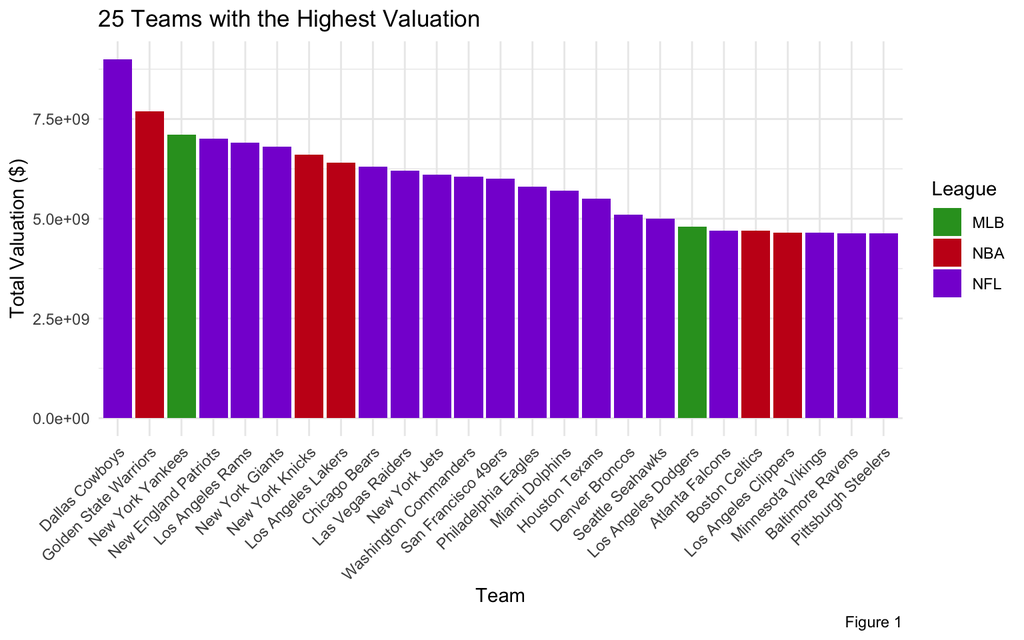

## Team Payroll

We then dove into the payroll commitments that teams make to their players. Utilizing another bar chart (Figure 2, below) to examine the top 25 teams (x-axis) with the highest payrolls (y-axis), we identified that 10 of these teams also appeared on the list of the 25 teams with the highest valuation. This observation, however, seemed less significant, indicating that less than half of the teams valued the highest don’t always allocate a proportionate share of their finances to player salaries. Of course, our inquiry only examines team spending over the most recent season. Nonetheless, we also found similar trends in the payroll graph to the valuation: 18 of the 25 highest payroll teams hailed from the NFL, while the remaining seven belonged to the MLB. This ultimately suggests that the NFL places substantial emphasis on player salaries compared to other leagues.

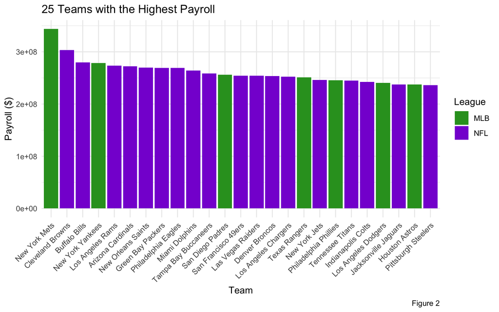

## Relationship between Payroll and Winning Percentage

In our analysis of winning percentage and payroll, we found there tends to be a positive relationship between how much players are paid and the teams’ success across all four leagues in the United States. We put together a scatter plot (Figure 3, below) containing each team with the team’s “Player Payroll” on the x-axis and the team’s “Winning Percentage” on the y-axis. This positive correlation suggests that a considerable investment in player salaries aligns with more success in professional sports in the United States. More success also generally leads to more ticket sales and investment in the franchise, which likely results in a higher valuation for the franchise. A higher payroll also signals that these teams have some of the best players in their respective leagues, as star players always charge more. These findings provide valuable insights into the intricate dynamics between financial investment in player talent and the competitive performance of sports teams, which ultimately go to show that, in most cases, teams that have more success are paying their players more, and also suggests that they have some of the most highly sought-after players in their league.

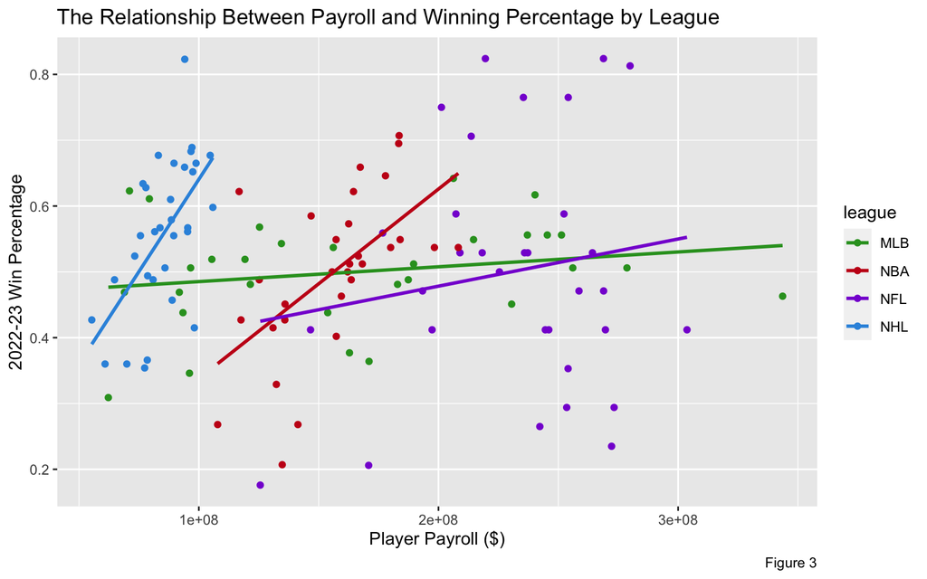

For context, the lines of best fit for the NHL and the NBA seem steeper in this last scatter plot because of scaling. Nonetheless, both the NHL and NBA have a stronger relationship with payroll and winning percentage than the NFL and the MLB. This is perhaps because the NHL and NBA have smaller rosters and fewer players on the field simultaneously. Therefore, a singular NHL or NBA superstar can turn a bad team into a good team, but they will also demand higher wages.

## Relationship Between Value and Payroll

We found that, across the major professional sports leagues in the United States, there is another discernible positive correlation between a team’s valuation and the investments made in player salaries. After creating a scatter plot (Figure 4, below) with “Valuation” on the x-axis and “Payroll” on the y-axis and including the teams from each league, we found a consistent pattern where teams with higher valuations tended to allocate more compensation towards their players. This was most evident when comparing the NHL and the NFL, as they have the most significant discrepancies between valuation and payroll. NHL franchises have, on average, lower valuations than any other league franchises in the United States. The opposite is true for the NFL, as football teams tend to have higher valuations than any other league franchises. To no one’s surprise, we see that the payroll for players who play for NFL teams tends to be higher than for players who play different sports.

Conversely, NHL players tend to make less than professional MLB, NBA, and NFL athletes. One interesting point that we took away from the scatter plot is that a decent amount of MLB teams pay their players more than the athletes in the NBA, even though the valuation of those MLB teams tends to be lower than the valuation of the NBA teams. This fact reveals that MLB teams may pay their players a disproportionate amount of money concerning the overall valuation of the franchise.

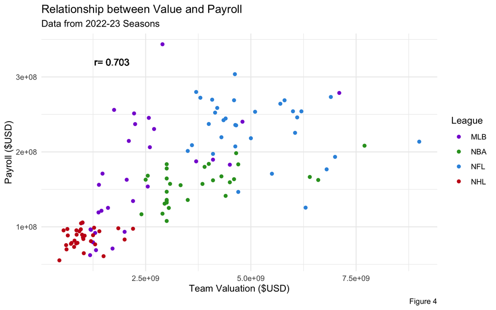

## Interactive Map: The Geographical Component

After successfully evaluating the relationship between a team’s value, payroll, and winning percentage, we looked into the geography of these teams as a possible connecting piece of the equation. We invite you to explore our interactive map to see geographical trends in value, winning percentage, and payroll between leagues. By our data, we find that, by and large, teams located in large cities like New York City, Los Angeles, Philadelphia, and Houston/Dallas had, on average, higher valuations and payrolls during 2022-23. The winning percentage looks like it varied by sport, confirming our findings from our payroll and winning percentage evaluation.

[interactive chart not shown]

# Limitations

Since our data collected was found on the Internet, it is possible that some figures could be slightly different from what is the case as it relates to payroll and valuation. Additionally, as it relates to payroll, the NFL actively tolerates teams being able to work around contracts, turning significant percentages of a player’s salary into a “signing bonus” as it does not affect the salary cap. Because of this, when looking at the NFL, teams towards the top of the league in payroll might spend more on their players than is represented by the payroll number.

Generally, this study’s results could be generalized to other sports in the United States. Still, it is being determined to what extent these would apply on the global stage. In Europe, larger cities might have large valuations and, thus, a higher payroll. However, it is tough to evaluate since soccer is a major sport in Europe, and the relationship between payroll and winning percentage might behave differently when extrapolated to a different geographic region and a different sport.

Extending this project to MLS (Major League Soccer) and sports leagues in Europe or Japan could be interesting to look at. However, we chose to stick with only the four major US sports because of the ease of access to the data. The data for these leagues isn’t as publicly available as was observed by our Shiny project.

# Conclusion

Altogether, our findings generally supported the prevailing narratives about professional sports in America that we sought to explore. First, we found that geography impacts how much a team is worth. We found that larger cities generally housed teams with a greater valuation and, consequently, a larger payroll. From a valuation and payroll standpoint, we found that the NFL dominated the four major US sports.

Exploring the relationships between team value, payroll, and winning percentage for the four major US sports leagues was fascinating. We hope these findings will shape our views and conversations on professional sports economics.

# References

Chang W, Cheng J, Allaire J, Sievert C, Schloerke B, Xie Y, Allen J, -McPherson J, Dipert A, Borges B (2023). *shiny: Web Application Framework for R*. R package version 1.7.5, https://CRAN.R-project.org/package=shiny.

Cheng J, Schloerke B, Karambelkar B, Xie Y (2023). *leaflet: Create Interactive Web Maps with the JavaScript ‘Leaflet’ Library*. R package version 2.2.0, https://CRAN.R-project.org/package=leaflet.

Forbes. (August 30, 2023). Franchise value of National Football League teams in 2023 (in billion U.S. dollars). In Statista. https://www.statista.com/statistics/193534/franchise-value-of-national-football-league-teams-in-2010/

Forbes. (December 14, 2022). National Hockey League franchise value in 2022, by team (in million U.S. dollars). In Statista. https://www.statista.com/statistics/193732/franchise-value-of-national-hockey-league-teams-in-2010/

Gough, Christina. “MLB Franchise Values 2023.” Statista, 5 Sept. 2023, https://www.statista.com/statistics/193637/franchise-value-of-major-league-baseball-teams-in-2010/.

“NFL 2022 Aav Tracker.” Spotrac.Com, https://www.spotrac.com/nfl/aav/2022/.

Statista Research Department, and Oct 30. “NBA Franchise Values 2023.” Statista, 30 Oct. 2023, https://www.statista.com/statistics/193696/franchise-value-of-national-basketball-association-teams-in-2010/.

Wickham H, Averick M, Bryan J, Chang W, McGowan LD, François R, Grolemund G, Hayes A, Henry L, Hester J, Kuhn M, Pedersen TL, Miller E, Bache SM, Müller K, Ooms J, Robinson D, Seidel DP, Spinu V, Takahashi K, Vaughan D, Wilke C, Woo K, Yutani H (2019). “Welcome to the tidyverse.” *Journal of Open Source Software*, *4*(43), 1686. doi:10.21105/joss.01686 https://doi.org/10.21105/joss.01686.

Wickham H, François R, Henry L, Müller K, Vaughan D (2023). *dplyr: A Grammar of Data Manipulation*. R package version 1.1.3, https://CRAN.R-project.org/package=dplyr.